# Relación de inversión per cápita con otros indicadores

# DATA INVERSIÓN PÚBLICA

**Por:** Carlos Mansilla

Antes de comenzar con la construcción y filtrados de datas sobre inversión pública, he de mencionar que la data de inversión pública de 2021-2025 ya está realizada al ver su relación con densidad poblacional. En consecuencia, solo se llamará para hacer las pruebas correspondientes.

## DATA INVERSIÓN PÚBLICA 2017-2021

Para relacionar la inversión pública en infraestructura educativa con la data de Índice de Desarrollo Humano (2019). Construimos la siguiente data:

Llamamos a la data:

```r
library(rio)
data = import("datos_categorizados3.xlsx")
```

Quitamos los valores irrelevantes que se catalogaron de manera manual:

```r
data <- data[data$CATEGORIA_INV != "NO RELEVANTE", ]
data <- data[data$CATEGORIA_INV != "NO RELACIONADO", ]
```

Para realizar las pruebas, preparo la fecha para realizar el filtrado adecuado:

```r
data$FECHA_REGISTRO <- substr(data$FECHA_REGISTRO, 1, 4)
```

Aquí filtro el año del 2017 hasta el 2021. La base de datos de IDH tiene su propia variable de densidad poblacional 2019.

```r
library(dplyr)
library(kableExtra)
data_filtrada <- data %>%
  filter(FECHA_REGISTRO >= 2017 & FECHA_REGISTRO <= 2021)
```

Para evitar sesgar los datos, se eliminan los outliers con el rango intercuantílico.

```r
Q1 <- quantile(data_filtrada$COSTO_ACTUALIZADO, 0.25, na.rm = TRUE)
Q3 <- quantile(data_filtrada$COSTO_ACTUALIZADO, 0.75, na.rm = TRUE)
IQR_val <- Q3 - Q1

#Definir límites (método estándar: 1.5 * IQR)
lim_inf <- Q1 - 1.5 * IQR_val
lim_sup <- Q3 + 1.5 * IQR_val

# Filtrar datos sin valores atípicos
data_filtrada <- data_filtrada %>%
  filter(COSTO_ACTUALIZADO >= lim_inf & COSTO_ACTUALIZADO <= lim_sup)
```

Vemos un boxplot para la comprobación, datos con outliers:

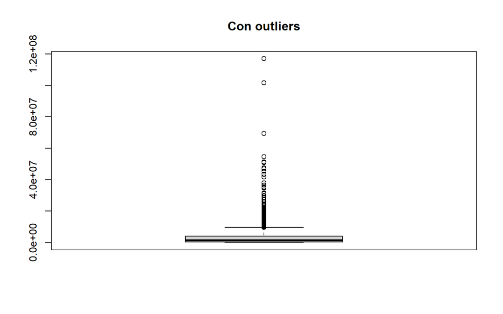

```r
boxplot(data$COSTO_ACTUALIZADO, main = "Con outliers")
```

Datos sin outliers

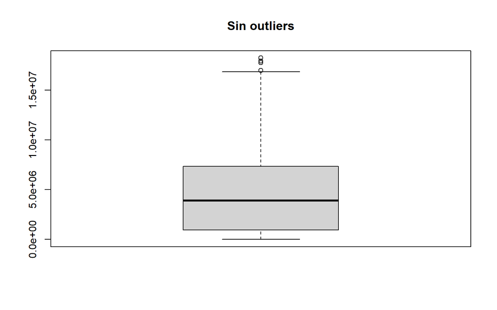

```r
boxplot(data_filtrada$COSTO_ACTUALIZADO, main = "Sin outliers")
```

Revisamos la distribución de los proyectos de inversión por año para ver si están bien distribuidos para realizar las pruebas:

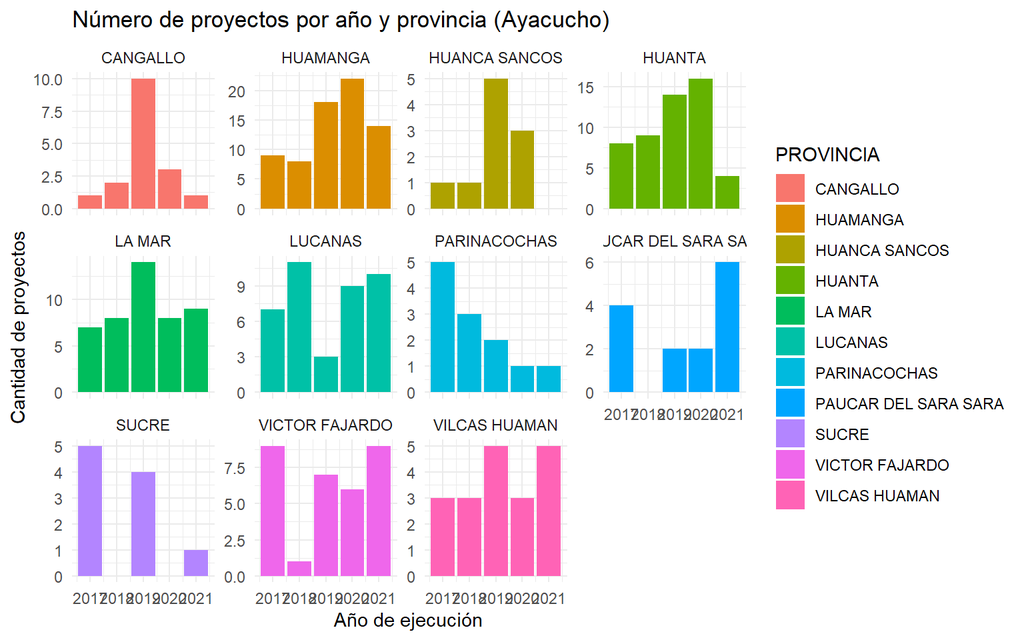

```r
library(dplyr)
library(ggplot2)

# Asegúrate de que ANIO_PROCESO esté bien tipado como numérico
data_filtrada$FECHA_REGISTRO <- as.numeric(data_filtrada$FECHA_REGISTRO)

# Tabla de número de proyectos por provincia y año
proyectos_por_anio <- data_filtrada %>%
  filter(!is.na(PROVINCIA), !is.na(FECHA_REGISTRO)) %>%
  group_by(PROVINCIA, FECHA_REGISTRO) %>%
  summarise(n = n(), .groups = "drop")

# Visualización rápida
ggplot(proyectos_por_anio, aes(x = FECHA_REGISTRO, y = n, fill = PROVINCIA)) +
  geom_col() +
  facet_wrap(~ PROVINCIA, scales = "free_y") +
  labs(title = "Número de proyectos por año y provincia (Ayacucho)",
       x = "Año de ejecución", y = "Cantidad de proyectos") +
  theme_minimal()
```

A primera vista vemos que hay algunas diferencias. Lo vemos más detenidamente:

```r
anio_promedio <- data_filtrada %>%
  filter(!is.na(PROVINCIA), !is.na(FECHA_REGISTRO), !is.na(COSTO_ACTUALIZADO)) %>%
  group_by(PROVINCIA) %>%
  summarise(
    anio_prom = mean(FECHA_REGISTRO, na.rm = TRUE),
    n_proyectos = n()
  ) %>%
  arrange(desc(anio_prom))

kable(anio_promedio,
      caption = "Promedio de años de los proyectos de inversión por provincia") %>%
  kable_styling(bootstrap_options = c("striped", "hover", "condensed"), full_width = FALSE)
```

Promedio de años de los proyectos de inversión por provincia

| PROVINCIA | anio_prom | n_proyectos |
| --- | --- | --- |
| PAUCAR DEL SARA SARA | 2019.429 | 14 |
| HUAMANGA | 2019.338 | 71 |
| VILCAS HUAMAN | 2019.211 | 19 |
| VICTOR FAJARDO | 2019.156 | 32 |
| LUCANAS | 2019.100 | 40 |
| LA MAR | 2019.087 | 46 |
| CANGALLO | 2019.059 | 17 |
| HUANCA SANCOS | 2019.000 | 10 |
| HUANTA | 2018.980 | 51 |
| SUCRE | 2018.200 | 10 |
| PARINACOCHAS | 2018.167 | 12 |

Aquí vemos que el año promedio se sitúa por el 2019. Por lo que podemos expresarlo por precios corrientes.

En esta “data_filtrada” lo agrupo por distrito y provincia:

```r
library(dplyr)

data_filtrada <- data_filtrada %>%
  group_by(DISTRITO, PROVINCIA, UBIGEO) %>%
  summarise(
    TOTAL_INVERSION = sum(COSTO_ACTUALIZADO, na.rm = TRUE)
  ) %>%
  arrange(desc(TOTAL_INVERSION))
```

Con esto tendría la data del monto de las inversiones realizadas desde el 2017 al 2021.

Sobre las cantidad de fechas, para no repetir información y realizar el presente documento muy extenso. No lo repetiré por aquí.

## INVERSIÓN PÚBLICA 2015-2019

Para hacer las pruebas con el Índice de Densidad Estatal del 2017. Se toma de referencia este año para filtrar la misma base de datos desde el 2015 hasta el 2019. Llamamos a la data anterior y la filtramos desde esa fecha:

```r
library(dplyr)
data_filtrada1 <- data %>%
  filter(FECHA_REGISTRO >= 2015 & FECHA_REGISTRO <= 2019)
```

Para evitar el sesgo de los outliers:

```r
Q1_1 <- quantile(data_filtrada1$COSTO_ACTUALIZADO, 0.25, na.rm = TRUE)
Q3_1 <- quantile(data_filtrada1$COSTO_ACTUALIZADO, 0.75, na.rm = TRUE)
IQR_val_1 <- Q3_1 - Q1_1

#Definir límites (método estándar: 1.5 * IQR)
lim_inf_1 <- Q1_1 - 1.5 * IQR_val_1
lim_sup_1 <- Q3_1 + 1.5 * IQR_val_1

# Filtrar datos sin valores atípicos
data_filtrada1 <- data_filtrada1 %>%
  filter(COSTO_ACTUALIZADO >= lim_inf_1 & COSTO_ACTUALIZADO <= lim_sup_1)
```

Datos sin outliers:

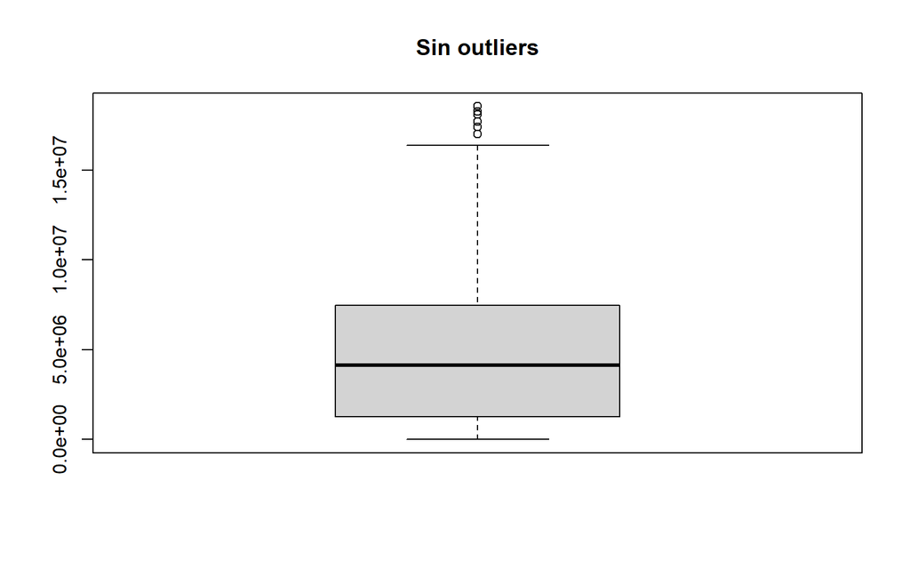

```r
boxplot(data_filtrada1$COSTO_ACTUALIZADO, main = "Sin outliers")
```

Revisamos la distribución de la cantidad de los proyectos por años:

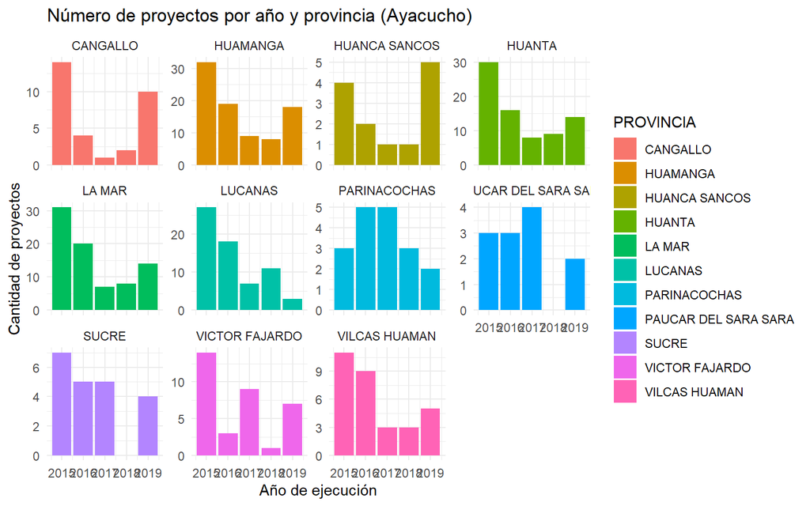

```r
library(dplyr)
library(ggplot2)

# Asegúrate de que ANIO_PROCESO esté bien tipado como numérico
data_filtrada1$FECHA_REGISTRO <- as.numeric(data_filtrada1$FECHA_REGISTRO)

# Tabla de número de proyectos por provincia y año
proyectos_por_anio <- data_filtrada1 %>%
  filter(!is.na(PROVINCIA), !is.na(FECHA_REGISTRO)) %>%
  group_by(PROVINCIA, FECHA_REGISTRO) %>%
  summarise(n = n(), .groups = "drop")

# Visualización rápida
ggplot(proyectos_por_anio, aes(x = FECHA_REGISTRO, y = n, fill = PROVINCIA)) +
  geom_col() +
  facet_wrap(~ PROVINCIA, scales = "free_y") +
  labs(title = "Número de proyectos por año y provincia (Ayacucho)",
       x = "Año de ejecución", y = "Cantidad de proyectos") +
  theme_minimal()
```

Hay similitudes, pero algunas diferencias. Lo vemos más de cerca:

```r
anio_promedio <- data_filtrada1 %>%
  filter(!is.na(PROVINCIA), !is.na(FECHA_REGISTRO), !is.na(COSTO_ACTUALIZADO)) %>%
  group_by(PROVINCIA) %>%
  summarise(
    anio_prom = mean(FECHA_REGISTRO, na.rm = TRUE),
    n_proyectos = n()
  ) %>%
  arrange(desc(anio_prom))

kable(anio_promedio,
      caption = "Promedio de años de los proyectos de inversión por provincia") %>%
  kable_styling(bootstrap_options = c("striped", "hover", "condensed"), full_width = FALSE)
```

Promedio de años de los proyectos de inversión por provincia

| PROVINCIA | anio_prom | n_proyectos |
| --- | --- | --- |
| HUANCA SANCOS | 2017.077 | 13 |
| PARINACOCHAS | 2016.778 | 18 |
| CANGALLO | 2016.677 | 31 |
| PAUCAR DEL SARA SARA | 2016.583 | 12 |
| HUAMANGA | 2016.547 | 86 |
| VICTOR FAJARDO | 2016.529 | 34 |
| HUANTA | 2016.494 | 77 |
| SUCRE | 2016.476 | 21 |
| LA MAR | 2016.425 | 80 |
| VILCAS HUAMAN | 2016.419 | 31 |
| LUCANAS | 2016.167 | 66 |

Vemos que los datos se concentran entre 2016. Por lo que procederemos con mantener los precios corrientes.

En esta “data_filtrada” lo agrupo por distrito y provincia:

```r
library(dplyr)

data_filtrada1 <- data_filtrada1 %>%
  group_by(DISTRITO, PROVINCIA, UBIGEO) %>%
  summarise(
    TOTAL_INVERSION = sum(COSTO_ACTUALIZADO, na.rm = TRUE)
  ) %>%
  arrange(desc(TOTAL_INVERSION))
```

Con esto tendría la data del monto de las inversiones realizadas desde el 2015 hasta el 2019.

# PRUEBAS CON OTROS DATOS

### ARMANDO LA DATA

Como mencioné al principio, ya hay una data armada. Llamamos ambas bases de datos:

```r
library(rio)
pobreza_monetaria = import("pobreza_monetaria_sumaria.csv")
inv_capita = import("inversion_per_capita.xlsx")
```

Cambiamos nombres:

```r
colnames(pobreza_monetaria)[6] <- "UBIGEO"
```

Filtramos el UBIGEO para poder realizar merge sin problemas:

```r
library(dplyr)
library(stringr)

pobreza_ayacucho <- pobreza_monetaria %>%
  filter(UBIGEO >= 49999 & UBIGEO <= 60000)
```

Clasificamos los datos de pobreza a partir de lo que se dice en el diccionario de variables:

```r
library(dplyr)
library(stringr)

pobreza_distrito <- pobreza_ayacucho %>%
  mutate(
    Pobreza = recode(as.character(POBREZA),
                     "1" = "Pobre Extremo",
                     "2" = "Pobre No Extremo",
                     "3" = "No Pobre")
  )
```

Agrupamos por UBIGEO y creamos una columna para contar la cantidad de casos por distrito. Luego, se calcula la proporción de casos donde la variable Pobreza es “Pobre Extremo”, “Pobre No Extremo” y “No Pobre”. Después, se encuentra la moda (la más frecuente) y la clasifica como tal.

```r
pobreza_distrito <- pobreza_distrito %>%
  group_by(UBIGEO) %>%
  summarise(
    n_casos             = n(),
    prop_pobre_extremo  = mean(Pobreza == "Pobre Extremo"),
    prop_pobre          = mean(Pobreza == "Pobre No Extremo"),
    prop_no_pobre       = mean(Pobreza == "No Pobre"),
    categoria_moda      = names(sort(table(Pobreza), decreasing = TRUE))[1],
    .groups = "drop"
  )
```

Revisamos brevemente la data de pobreza construida:

```r
kable(head(pobreza_distrito,10),
      caption = "Primeras 10 observaciones de la data de pobreza") %>%
  kable_styling(bootstrap_options = c("striped", "hover", "condensed"), full_width = FALSE)
```

Primeras 10 observaciones de la data de pobreza

| UBIGEO | n_casos | prop_pobre_extremo | prop_pobre | prop_no_pobre | categoria_moda |
| --- | --- | --- | --- | --- | --- |
| 50101 | 149 | 0.0067114 | 0.1342282 | 0.8590604 | No Pobre |
| 50102 | 15 | 0.1333333 | 0.5333333 | 0.3333333 | Pobre No Extremo |
| 50103 | 30 | 0.1333333 | 0.2666667 | 0.6000000 | No Pobre |
| 50104 | 36 | 0.1944444 | 0.1944444 | 0.6111111 | No Pobre |
| 50105 | 8 | 0.0000000 | 0.6250000 | 0.3750000 | Pobre No Extremo |
| 50106 | 6 | 0.0000000 | 0.1666667 | 0.8333333 | No Pobre |
| 50107 | 8 | 0.2500000 | 0.6250000 | 0.1250000 | Pobre No Extremo |
| 50108 | 14 | 0.0000000 | 0.1428571 | 0.8571429 | No Pobre |
| 50110 | 45 | 0.0222222 | 0.1111111 | 0.8666667 | No Pobre |
| 50111 | 6 | 0.0000000 | 0.5000000 | 0.5000000 | No Pobre |

Convertimos el UBIGEO en character para evitar problemas al unir las bases de datos:

```r
inv_capita$UBIGEO = as.character(inv_capita$UBIGEO)
pobreza_distrito$UBIGEO = as.character(pobreza_distrito$UBIGEO)
```

Unimos ambas bases de datos:

```r
data_pobreza <- inv_capita %>%
  left_join(pobreza_distrito, by = "UBIGEO")
```

Revisamos la cantidad de NA’s:

```r
nrow(inv_capita)      # total de distritos en inversión
```

```
## [1] 120
```

```r
sum(is.na(data_pobreza$prop_pobre))  # debe ser 0 si todo se unió bien
```

```
## [1] 52
```

Vemos que de 120 datos, se perdieron 52 datos.

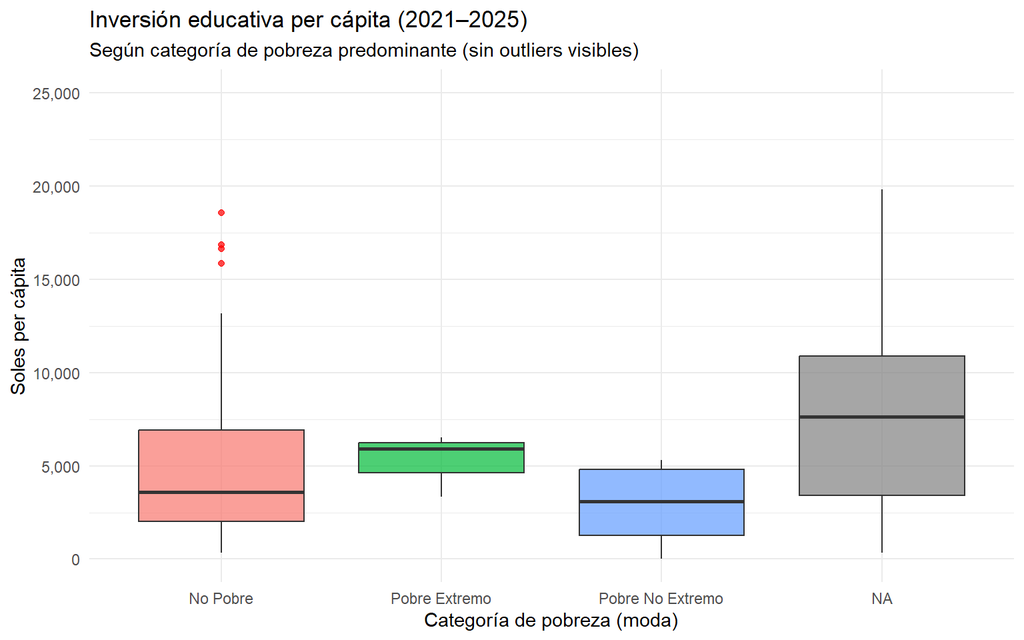

```r
library(ggplot2)

ggplot(data_pobreza, aes(x = categoria_moda, y = INVERSION_PER_CAPITA, fill = categoria_moda)) +
  geom_boxplot(outlier.color = "red", alpha = 0.7) +
  scale_y_continuous(labels = scales::comma) +
  coord_cartesian(ylim = c(0, 25000)) +  # Ajusta según tu contexto
  labs(title = "Inversión educativa per cápita (2021–2025)",
       subtitle = "Según categoría de pobreza predominante (sin outliers visibles)",
       x = "Categoría de pobreza (moda)", y = "Soles per cápita") +
  theme_minimal() +
  theme(legend.position = "none")
```

**INTERPRETACIÓN:** Anteriormente (cuando olvidé filtrar la data de inversión y estaba con outliers) se visualizaba que outliers en NA generaba una dispersión de datos que no permitía observar bien los bloxplots. Ahora, mediante esto, se puede observar que:

- Algunos distritos “No pobres” pueden haber recibido proyectos grandes puntuales, pero la mayoría no tiene alta inversión
- Sobre los distritos “Pobre Extremo”, son una posible prioridad del Estado aunque *no son excepcionales*.
- Sobre los distritos “Pobre No Extremo” podrían estar siendo menos atendidos que los extremos.

ENTONCES, la categoría de pobreza predominante no se asocia directamente con una mayor inversión educativa per cápita.

### CORRELACIONES

Empezamos a ver la correlación entre Pobreza (desde sus 3 niveles) junto con inversión per cápita (calculada en la prueba con densidad poblacional).

Quitamos los NA’s para evitar sesgos en la correlación:

```r
data_cor <- data_pobreza %>%
  filter(!is.na(INVERSION_PER_CAPITA),
         !is.na(prop_pobre),
         !is.na(prop_pobre_extremo),
         !is.na(prop_no_pobre))
```

Realizamos las correlaciones Spearman:

```r
cor.test(data_cor$INVERSION_PER_CAPITA, data_cor$prop_pobre, method = "spearman")
```

```
##
##  Spearman's rank correlation rho
##
## data:  data_cor$INVERSION_PER_CAPITA and data_cor$prop_pobre
## S = 55125, p-value = 0.4209
## alternative hypothesis: true rho is not equal to 0
## sample estimates:
##         rho
## -0.09995739
```

```r
cor.test(data_cor$INVERSION_PER_CAPITA, data_cor$prop_pobre_extremo, method = "spearman")
```

```
##
##  Spearman's rank correlation rho
##
## data:  data_cor$INVERSION_PER_CAPITA and data_cor$prop_pobre_extremo
## S = 41189, p-value = 0.1493
## alternative hypothesis: true rho is not equal to 0
## sample estimates:
##       rho
## 0.1781189
```

```r
cor.test(data_cor$INVERSION_PER_CAPITA, data_cor$prop_no_pobre, method = "spearman")
```

```
##
##  Spearman's rank correlation rho
##
## data:  data_cor$INVERSION_PER_CAPITA and data_cor$prop_no_pobre
## S = 54087, p-value = 0.5239
## alternative hypothesis: true rho is not equal to 0
## sample estimates:
##         rho
## -0.07924166
```

**INTERPRETACIÓN:** A partir de estas correlaciones de Spearman, destaco que el signo de prop_pobre_extremo es positivo (0.18), lo cual puede parecer intuitivo porque establece que a mayor pobreza extrema, mayor es la inversión. No obstamte, es débil y no significativo. A comparación de otras correlaciones referente a pobreza no extrema (-0.09) que refiere a que a mayor pobreza, menor es la inversión. Finalmente estaría la relación entre no pobre (-0.08) que indica que mayor sea el “desarrollo” de distritos no pobres, menor será la inversión.

Entonces, no se encontró evidencia estadísticamente significativa entre la proporción de población pobre (ni pobre extremo ni no pobre) y la inversión educativa per cápita en infraestructura educativa sobre los distritos de Ayacucho entre 2021 y 2025. Por tanto, la asignación de inversión no se está guiando por criterios directos de pobreza e incluso pueden haber otras variables mediadoras (población total, infraestructura previa, factores geográficos, etc.).

Revisamos las correlaciones de Pearsons para ver si hay relación lineal:

```r
cor.test(data_cor$INVERSION_PER_CAPITA, data_cor$prop_pobre, method = "pearson")
```

```
##
##  Pearson's product-moment correlation
##
## data:  data_cor$INVERSION_PER_CAPITA and data_cor$prop_pobre
## t = -1.1595, df = 65, p-value = 0.2505
## alternative hypothesis: true correlation is not equal to 0
## 95 percent confidence interval:
##  -0.3699171  0.1013151
## sample estimates:
##        cor
## -0.1423581
```

```r
cor.test(data_cor$INVERSION_PER_CAPITA, data_cor$prop_pobre_extremo, method = "pearson")
```

```
##
##  Pearson's product-moment correlation
##
## data:  data_cor$INVERSION_PER_CAPITA and data_cor$prop_pobre_extremo
## t = 1.2161, df = 65, p-value = 0.2284
## alternative hypothesis: true correlation is not equal to 0
## 95 percent confidence interval:
##  -0.09444537  0.37588878
## sample estimates:
##       cor
## 0.1491469
```

```r
cor.test(data_cor$INVERSION_PER_CAPITA, data_cor$prop_no_pobre, method = "pearson")
```

```
##
##  Pearson's product-moment correlation
##
## data:  data_cor$INVERSION_PER_CAPITA and data_cor$prop_no_pobre
## t = 0.074174, df = 65, p-value = 0.9411
## alternative hypothesis: true correlation is not equal to 0
## 95 percent confidence interval:
##  -0.2315205  0.2488584
## sample estimates:
##        cor
## 0.00919971
```

**INTERPRETACIÓN:** Observamos que no hay casi nada nuevo, el cambio no es significativo. La correlación subió un poco con prop_pobre a -0.14 lo que indicaría que existan distritos con alta pobreza pero baja inversión.

Preparamos la data para realizar un modelo:

```r
data_modelo <- data_pobreza %>%
  filter(!is.na(INVERSION_PER_CAPITA),
         !is.na(prop_pobre),
         !is.na(prop_pobre_extremo))
```

```r
modelo <- lm(INVERSION_PER_CAPITA ~ prop_pobre + prop_pobre_extremo, data = data_modelo)
summary(modelo)
```

```
##
## Call:
## lm(formula = INVERSION_PER_CAPITA ~ prop_pobre + prop_pobre_extremo,
##     data = data_modelo)
##
## Residuals:
##    Min     1Q Median     3Q    Max
##  -6616  -3099  -1503   1199  20956
##
## Coefficients:
##                    Estimate Std. Error t value Pr(>|t|)
## (Intercept)            5660       1166   4.854 8.13e-06 ***
## prop_pobre            -4576       3667  -1.248    0.217
## prop_pobre_extremo     5479       4214   1.300    0.198
## ---
## Signif. codes:  0 '***' 0.001 '**' 0.01 '*' 0.05 '.' 0.1 ' ' 1
##
## Residual standard error: 5031 on 64 degrees of freedom
## Multiple R-squared:  0.04547,    Adjusted R-squared:  0.01564
## F-statistic: 1.524 on 2 and 64 DF,  p-value: 0.2255
```

**INTERPRETACIÓN:** No hay mucha información nueva, sigue siendo no significativo.

POR TANTO, **no podemos asegurar que la inversión responde al grado de pobreza de un distrito.**

## ÍNDICE DE DESARROLLO HUMANO 2019

### ARMANDO LA DATA

Llamamos a la data de IDH:

```r
library(rio)
IDH = import("IDH-y-Componentes-2003-2019.xlsx")
```

Con este código vamos a cambiar los nombres de la base de datos para que sea más accesible:

```r
library(dplyr)
library(stringr)

colnames(IDH)[5] <- "CANTIDAD_POBLACIÓN"
colnames(IDH)[6] <- "ESPERANZA_VIDA"
colnames(IDH)[7] <- "SEC_COMPLETA_18"
colnames(IDH)[8] <- "ANIOS_EDUC_25"
colnames(IDH)[9] <- "INGRESO_FAMILIAR_P_CAPITA"
colnames(IDH)[10] <- "ESPERANZA_VIDA_2"
colnames(IDH)[11] <- "SEC_COMPLETA_18_2"
colnames(IDH)[12] <- "ANIOS_EDUC_25_2"
colnames(IDH)[13] <- "LOGROS_EDUCATIVOS"
colnames(IDH)[14] <- "INGRESO_FAMILIAR_P_CAPITA2"
colnames(IDH)[15] <- "IDH_2019"
```

Filtramos la data por departamento:

```r
library(dplyr)

idh_ayacucho <- IDH %>%
  filter(DEPARTAMENTO == "AYACUCHO") %>%
  select(
    UBIGEO,
    PROVINCIA,
    DISTRITO,
    IDH_2019,
    CANTIDAD_POBLACIÓN)
```

Quitamos los NA’s que se mantienen en la columna de DISTRITO:

```r
idh_ayacucho <- idh_ayacucho %>%
  filter(!is.na(DISTRITO))
```

Quitamos el 0 del UBIGEO de la data de IDH:

```r
idh_ayacucho$UBIGEO <- sub("^0", "", idh_ayacucho$UBIGEO)
```

Convertimos el UBIGEO en character para preparar la unión:

```r
idh_ayacucho$UBIGEO <- as.character(idh_ayacucho$UBIGEO)
data_filtrada$UBIGEO <- as.character(data_filtrada$UBIGEO)
```

Unimos las bases de datos:

```r
data_final1 <- left_join(idh_ayacucho, data_filtrada, by = "UBIGEO")
```

Quitamos las columnas repetidas:

```r
data_final1 <- data_final1 %>%
  select(-DISTRITO.y, -PROVINCIA.y)
```

Cambiamos los nombres para evitar problemas:

```r
colnames(data_final1)[2] <- "PROVINCIA"
colnames(data_final1)[3] <- "DISTRITO"
colnames(data_final1)[5] <- "DEN_POB_2019"
```

Calculamos la inversión per cápita 2019:

```r
data_final1 <- data_final1 %>%
  mutate(INVERSION_PER_CAPITA_2019 = TOTAL_INVERSION / DEN_POB_2019)
```

### CORRELACIONES

Vamos a ver la correlación entre IDH y la inversión per cápita:

```r
cor.test(data_final1$INVERSION_PER_CAPITA_2019, data_final1$IDH_2019, method = "pearson")
```

```
##
##  Pearson's product-moment correlation
##
## data:  data_final1$INVERSION_PER_CAPITA_2019 and data_final1$IDH_2019
## t = -1.1276, df = 94, p-value = 0.2624
## alternative hypothesis: true correlation is not equal to 0
## 95 percent confidence interval:
##  -0.30885793  0.08697487
## sample estimates:
##        cor
## -0.1155255
```

```r
cor.test(data_final1$INVERSION_PER_CAPITA_2019, data_final1$IDH_2019, method = "spearman")
```

```
##
##  Spearman's rank correlation rho
##
## data:  data_final1$INVERSION_PER_CAPITA_2019 and data_final1$IDH_2019
## S = 197958, p-value = 0.000678
## alternative hypothesis: true rho is not equal to 0
## sample estimates:
##        rho
## -0.3426343
```

**INTERPRETACIÓN:** ENTONCES, hay evidencia significativa de una relación negativa no lineal entre inversión per cápita e IDH (percibida en la prueba de correlación Spearman con un -0.34). Esto podría reflejar que la inversión se concentra en distritos más rezagados, que tienen menor IDH. Es decir, el Estado estaría priorizando la inversión donde el desarrollo es más bajo. Por tanto:

- La inversión *aumenta* mucho en los distritos con IDH muy bajo (porque necesitan más)
- Pero luego se estabiliza o incluso *disminuye* en distritos con IDH medio o alto.

Revisamos estas afirmaciones con el siguiente gráfico:

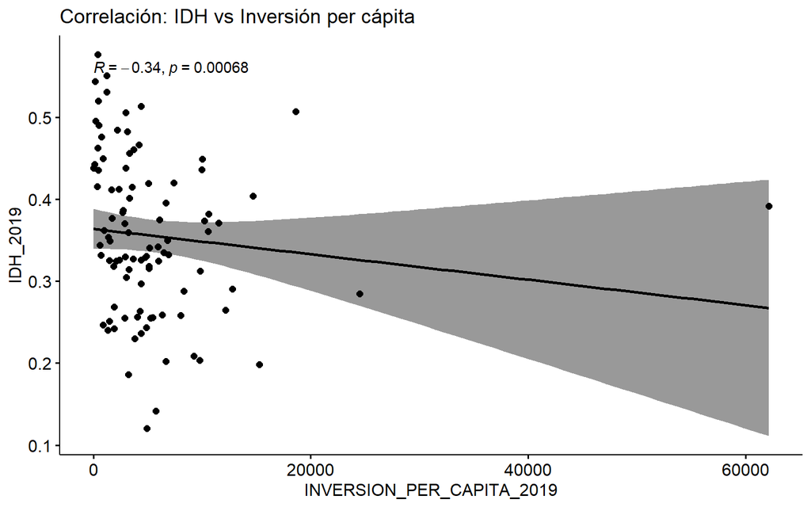

```r
library(ggpubr)

ggscatter(data_final1,
          x = "INVERSION_PER_CAPITA_2019",
          y = "IDH_2019",
          add = "reg.line",
          conf.int = TRUE,
          cor.coef = TRUE,
          cor.method = "spearman") +
  labs(title = "Correlación: IDH vs Inversión per cápita")
```

**INTERPRETACIÓN:** Hay distritos con alta inversión y bajo IDH, pero también casos contrarios; es decir, baja inversión y alto IDH. Esta dispersión sugiere que otros factores (como la densidad poblacional, las prioridades sectoriales o la gestión local) también podrían estar influyendo en el patrón de inversión.

Sin embargo, es necesario recalcar que hay datos referentes a bajo IDH y, a su vez, baja inversión per cápita. Esto podría indicar que la inversión no se está distribuyendo equitativamente entre los distritos con menor IDH:

```r
bajoIDH_bajaI = data_final1 %>%
  filter(IDH_2019 < 0.3, INVERSION_PER_CAPITA_2019 < 5000) %>%
  arrange(IDH_2019) %>%
  select(PROVINCIA, DISTRITO, IDH_2019, INVERSION_PER_CAPITA_2019)


kable(bajoIDH_bajaI,
      caption = "Distritos y Provincias con menos inversión y menor nivel del IDH 2019") %>%
  kable_styling(bootstrap_options = c("striped", "hover", "condensed"), full_width = FALSE)
```

Distritos y Provincias con menos inversión y menor nivel del IDH 2019

| PROVINCIA | DISTRITO | IDH_2019 | INVERSION_PER_CAPITA_2019 |
| --- | --- | --- | --- |
| HUANTA | Chaca | 0.1202441 | 4929.7832 |
| HUAMANGA | Vinchos | 0.1859776 | 3207.2706 |
| HUAMANGA | Ocros | 0.2301277 | 3791.9077 |
| LUCANAS | San Cristobal | 0.2361608 | 4408.7975 |
| HUAMANGA | Socos | 0.2405484 | 1335.6267 |
| LA MAR | Tambo | 0.2421151 | 1922.6571 |
| LA MAR | Anchihuay | 0.2436337 | 4896.9369 |
| HUANTA | Santillana | 0.2464272 | 877.6091 |
| HUAMANGA | Acocro | 0.2511978 | 1486.5863 |
| HUAMANGA | Acos Vinchos | 0.2550089 | 2891.1205 |
| HUANTA | Ayahuanco | 0.2565903 | 4031.2545 |
| VICTOR FAJARDO | Huamanquiquia | 0.2631798 | 4283.4622 |
| PARINACOCHAS | Upahuacho | 0.2683871 | 1903.8231 |
| HUAMANGA | San Jose De Ticllas | 0.2971308 | 4401.2351 |

**INTERPRETACIÓN:** Aquí observamos los distritos cuales tienen bajo nivel de IDH y baja inversión per cápita.

## ÍNDICE DE DENSIDAD ESTATAL 2017

### ARMANDO LA DATA

Llamamos a la data de densidad estatal:

```r
library(rio)
densidad_estatal = import("IDE-2007-2017.xlsx")
```

Cambiamos los nombres para evitar complicaciones:

```r
library(dplyr)
library(stringr)

colnames(densidad_estatal)[1] <- "UBIGEO"
colnames(densidad_estatal)[2] <- "DEPARTAMENTO"
colnames(densidad_estatal)[3] <- "PROVINCIA"
```

Filtramos la data por departamento:

```r
library(dplyr)

dens_estatal_aya <- densidad_estatal %>%
  filter(DEPARTAMENTO == "Ayacucho") %>%
  select(UBIGEO, DEPARTAMENTO,
    PROVINCIA,
    CANTIDAD_POBLACIÓN_2017, IDE_2017)
```

Quitamos el 0 perteneciente a UBIGEO para unir bases de datos:

```r
dens_estatal_aya$UBIGEO <- sub("^0", "", dens_estatal_aya$UBIGEO)
```

Convertimos el UBIGEO en character para evitar problemas al unir las bases de datos:

```r
data_filtrada1$UBIGEO = as.character(data_filtrada1$UBIGEO)
dens_estatal_aya$UBIGEO = as.character(dens_estatal_aya$UBIGEO)
```

Aquí convertimos todos los datos de la columna PROVINCIA a mayúsculas y eliminamos las tildes para evitar problemas al unir las bases de datos:

```r
library(dplyr)
library(stringi)

dens_estatal_aya <- dens_estatal_aya %>%
  mutate(PROVINCIA = toupper(stri_trans_general(PROVINCIA, "Latin-ASCII")))
```

Llamamos a la otra data y la filtramos solo por provincia, ya on por distrito:

```r
data_filtrada1 <- data_filtrada1 %>%
  group_by(PROVINCIA) %>%
  summarise(TOTAL_INVERSION_PROVINCIA = sum(TOTAL_INVERSION, na.rm = TRUE)) %>%
  ungroup()
```

Unimos las bases de datos:

```r
data_final2 <- left_join(dens_estatal_aya, data_filtrada1, by = "PROVINCIA")
```

Calculamos la inversión per cápita 2017:

```r
data_final2 <- data_final2 %>%
  mutate(INVERSION_PER_CAPITA_2017 = TOTAL_INVERSION_PROVINCIA / CANTIDAD_POBLACIÓN_2017)
```

### CORRELACIONES

Vamos a ver la correlación entre IDE y la inversión per cápita:

```r
cor.test(data_final2$INVERSION_PER_CAPITA_2017, data_final2$IDE_2017, method = "pearson")
```

```
##
##  Pearson's product-moment correlation
##
## data:  data_final2$INVERSION_PER_CAPITA_2017 and data_final2$IDE_2017
## t = -2.2601, df = 9, p-value = 0.05017
## alternative hypothesis: true correlation is not equal to 0
## 95 percent confidence interval:
##  -0.882902949 -0.002879619
## sample estimates:
##        cor
## -0.6017152
```

**INTERPRETACIÓN:** Con una correlación de -0.60, tenemos que mientras mayor sea la inversión pública per cápita, menor será la densidad estatal (IDE). Es decir, en las provincias donde el Estado está menos presente (según el IDE), se estaría invirtiendo más por persona.

NO OBSTANTE, el p-valor sobrepasa **por muy poco** el límite, por lo que podemos tomar esta información como indicio.

```r
cor.test(data_final2$INVERSION_PER_CAPITA_2017, data_final2$IDE_2017, method = "spearman")
```

```
##
##  Spearman's rank correlation rho
##
## data:  data_final2$INVERSION_PER_CAPITA_2017 and data_final2$IDE_2017
## S = 338, p-value = 0.09364
## alternative hypothesis: true rho is not equal to 0
## sample estimates:
##        rho
## -0.5363636
```

**INTERPRETACIÓN:** Aquí sí vemos que sobrepasa el límite y se vuelve completamente no significativo.

ENTONCES, los datos sugieren (desde la correlación Spearman) que cuando el Estado es menos presente, se invierte más por persona (como una forma de compensación). Sin embargo, estas pruebas no son contundentes porque el p-valor está cerca o por encima de 0.05. Esto se puede deber a que **las observaciones solo se concentran en las provincias**, por lo que hay poco nivel de análisis estadístico.

Igualmente revisamos la dispersión de los datos desde el siguiente gráfico:

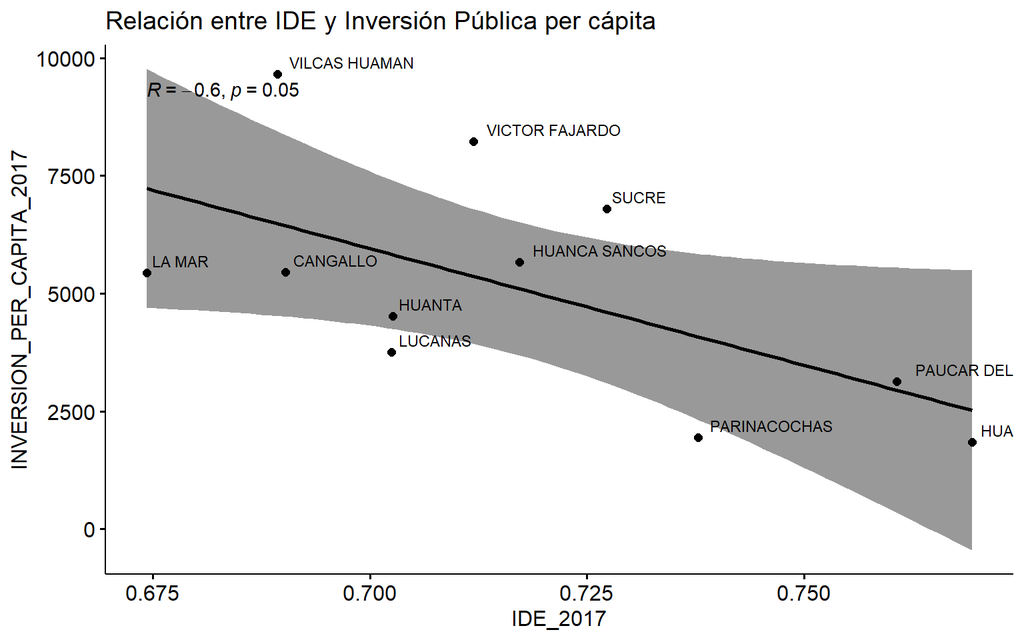

```r
library(ggpubr)
library(ggplot2)

ggscatter(data_final2,
          x = "IDE_2017",
          y = "INVERSION_PER_CAPITA_2017",
          add = "reg.line",
          conf.int = TRUE,
          cor.coef = TRUE,
          cor.method = "pearson") +
  geom_text(aes(label = PROVINCIA), hjust = -0.1, vjust = -0.5, size = 3) +
  labs(title = "Relación entre IDE y Inversión Pública per cápita")
```

**INTERPRETACIÓN:** En el gráfico, provincias como VILCAS HUAMÁN y VÍCTOR FAJARDO, con un IDE relativamente bajo, presentan altos niveles de inversión per cápita. Por otro lado, provincias como PAUCAR DEL SARA SARA y HUAMANGA, con un IDE más alto, exhiben valores más bajos de inversión per cápita. LA MAR sería el caso en el que pese a tener un IDE bajo, la inversión per cápita es moderada. Esto sugiere que la inversión pública no necesariamente se distribuye de manera uniforme en función de la presencia estatal, lo que podría indicar una priorización de ciertos distritos o provincias en función de otros criterios.